# Julia_Moffitt_Final_Version_DL_For_Malaria_Detection

## **Automatic detection of malaria from erythrocytes: Optimization of a deep learning CNN model. Final Submission**

Julia A. Moffitt, PhD

**Problem Definition**

The context:

- Malaria continues to exact an enormous global health burden, despite a clear understanding of mechanisms, method of detection and means for prevention and treatment (5).
- Despite global trends in reducing case incidence rate, progress towards milestones has reversed in some areas, particularly in Sub-Saharan Africa, where rates of malaria are among the highest (5).
- Countries with the highest rates of malaria have the fewest economic resources to devote to tackling the problem (5).
- Disruptions in resource allocations due to COVID have also impeded progress (5).
- Rapid, accurate detection of malaria is important as delays in diagnosis and treatment increase mortality.
- Malaria is caused by parasitic transmission of the Plasmodium group through infected mosquito bites (3).
- Malaria has traditionally been diagnosed through manual microscopic examination of stained blood smears, a tedious process dependent on trained operators and prone to error (3).
- Recent advances in AI an computer vision technology have enabled the detection of malaria through automated means (1-4).
- Despite these advances, use of peripheral blood smear remains the primary means of diagnosing malaria (1).
- Ideally, a method by which automatic visual inspection of parasitized erythrocytes (red blood cells; RBCs) deployed on a smartphone would allow for rapid diagnosis in any setting (1,2).

**The overall goal** of this project is to contribute to maximizing malaria detection through development of deep learning models, while minimizing computational resource needs.

**The objective** of this project is to build on currently established CNN deep learning models for the detection of malaria in RBCs to optimize the model to reduce computing resources while maintaining a high level of accuracy.

**The key questions:**

- Can an accurate CNN model be developed that can be deployed with minimal computational needs? (i.e. from a smartphone)
- Does training the model with a correctly labeled data set lead to better performance?
- What are the ideal parmameters to use for the model?
- Do the data need augmentation or is it not necessary?

**The problem formulation:**

- Correctly identifying and classifying images of RBCs as either parasitized or uninfected with malaria is the key objective in development of this model. Becuase this is a medical diagnostic use, it is imperative that the model perform with extremely high accuracy and very low error.
- The overall goal is to construct a highly effective model that uses as few layers and computational resources necessary so it may deployed on smartphones for use in remote areas in countries with fewer resources.

**Data Description**

- In the original assignmnet there were a total of 24,958 train and 2,600 test images (colored) that were taken from microscopic images.
- Prior to initiating the project a literature search on PubMed was conducted. Within that search an article by Fuhad et. al. 2020 took the above data set and cleaned and correctly labeled it with the assistance of an expert (2). Some ambigouous images were removed and others had labels corrected. This resulted in 13,029 uninfected and 13,132 parasitized images.
- It is the goal of this project to use the correctly labeled and updated data set in the development of the model. Corrected Malaria Data—Google Drive. [(accessed on 29 December 2019)];2019 Available online: https://drive.google.com/drive/folders/10TXXa6B_D4AKuBV085tX7UudH1hINBRJ?usp=sharing.

**These images are of the following categories:**

**Parasitized:** The parasitized cells contain the Plasmodium parasite which causes malaria **Uninfected:** The uninfected cells are free of the Plasmodium parasites

**Citations**

1. Eze PU, Asogwa CO. Deep Machine Learning Model Trade-Offs for Malaria Elimination in Resource-Constrained Locations. Bioengineering (Basel). 2021 Oct 21;8(11):150. doi: 10.3390/bioengineering8110150. PMID: 34821716; PMCID: PMC8614791.
2. Fuhad KMF, Tuba JF, Sarker MRA, Momen S, Mohammed N, Rahman T. Deep Learning Based Automatic Malaria Parasite Detection from Blood Smear and its Smartphone Based Application. Diagnostics (Basel). 2020 May 20;10(5):329. doi: 10.3390/diagnostics10050329. PMID: 32443868; PMCID: PMC7277980.
3. Li S, Du Z, Meng X, Zhang Y. Multi-stage malaria parasite recognition by deep learning. Gigascience. 2021 Jun 17;10(6):giab040. doi: 10.1093/gigascience/giab040. PMID: 34137821; PMCID: PMC8210472.
4. Poostchi M, Silamut K, Maude RJ, Jaeger S, Thoma G. Image analysis and machine learning for detecting malaria. Transl Res. 2018 Apr;194:36-55. doi: 10.1016/j.trsl.2017.12.004. Epub 2018 Jan 12. PMID: 29360430; PMCID: PMC5840030. World Malaria Report 2020, World Health Organization. https://www.who.int/publications/i/item/9789240015791

### **Mounting the Drive**

```python
#Mounting the drive
from google.colab import drive
drive.mount('/content/drive')
```

```python
drive.mount("/content/drive", force_remount=True)
```

### **Loading libraries**

```python
#Importing libraries required to load the data

import zipfile
import os
from PIL import Image
import numpy as np
import pandas as pd
import matplotlib.pyplot as plt
import seaborn as sns

from sklearn.model_selection import train_test_split
from sklearn.preprocessing import MinMaxScaler

import tensorflow as tf
from tensorflow.keras.models import Sequential
from tensorflow.keras.layers import Dense, Conv2D, MaxPool2D, BatchNormalization, Dropout, Flatten, LeakyReLU, GlobalAvgPool2D, LayerNormalization
from tensorflow.keras.utils import to_categorical
from tensorflow.keras import optimizers

#to ignore warnings
import warnings
warnings.filterwarnings('ignore')

# Remove the limit from the number of displayed columns and rows. It helps to see the entire dataframe while printing it
pd.set_option("display.max_columns", None)
pd.set_option("display.max_rows", 200)
```

### **Loading the corrected data set provided from Fuhad et al. 2020**

**Source:** Corrected Malaria Data—Google Drive. [(accessed on 29 December 2019)];2019 Available online: https://drive.google.com/drive/folders/10TXXa6B_D4AKuBV085tX7UudH1hINBRJ?usp=sharing.

These images are of the following categories:

- True Parasitized: The parasitized cells contain the Plasmodium parasite which causes malaria.
- True Uninfected: The uninfected cells are free of the Plasmodium parasites

```python
#Load True Parasatized Data Set from the Google drive
path = '/content/drive/MyDrive/Updated_Cell_Images/True_parasitized-20211229T200549Z-001.zip'

#The data is provided as a zip file so we need to extract the files from the zip file
with zipfile.ZipFile(path, 'r') as zip_ref:
    zip_ref.extractall()
```

```python
#Load True Uninfected Data Set from the Google drive
path = '/content/drive/MyDrive/Updated_Cell_Images/True_uninfected-20211229T205351Z-001.zip'

#The data is provided as a zip file so we need to extract the files from the zip file
with zipfile.ZipFile(path, 'r') as zip_ref:
    zip_ref.extractall()
```

```python
#importing additional libraries that will be needed for image processing
import cv2
import matplotlib.pyplot as plt
import seaborn as sns
import os
from PIL import Image
from keras.preprocessing.image import img_to_array
from keras.preprocessing.image import load_img
from keras.utils import np_utils
%load_ext tensorboard
import datetime
```

```python
parasitized_data = os.listdir('/content/True_parasitized')
print(parasitized_data[:10]) #the output we get are the .png files

uninfected_data = os.listdir('/content/True_uninfected')
print('\n')
print(uninfected_data[:10])
```

```
['C149P110ThinF_IMG_20151115_115154_cell_253.png', 'C133P94ThinF_IMG_20151004_155331_cell_122.png', 'C59P20thinF_IMG_20150803_112858_cell_196.png', 'C129P90ThinF_IMG_20151004_133703_cell_87.png', 'C183P144NThinF_IMG_20151201_223758_cell_129.png', 'C118P79ThinF_IMG_20151002_110834_cell_146.png', 'C59…


['C110P71ThinF_IMG_20150930_105319_cell_158.png', 'C94P55ThinF_IMG_20150821_170249_cell_153.png', 'C234ThinF_IMG_20151112_162909_cell_7.png', 'C136P97ThinF_IMG_20151005_144727_cell_24.png', 'C107P68ThinF_IMG_20150924_222630_cell_74.png', 'C72P33_ThinF_IMG_20150815_104307_cell_169.png', 'C219ThinF_IM…
```

Visualizing PARASITIZED and UNINFECTED images from each folder.

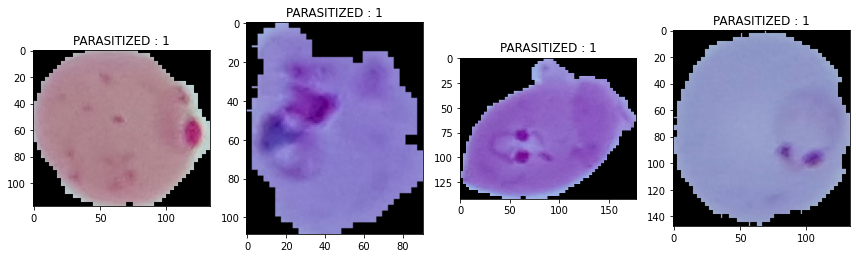

```python
plt.figure(figsize = (12,12))
for i in range(4):
    plt.subplot(1, 4, i+1)
    img = cv2.imread('/content/True_parasitized' + "/" + parasitized_data[i])
    plt.imshow(img)
    plt.title('PARASITIZED : 1')
    plt.tight_layout()
plt.show()
```

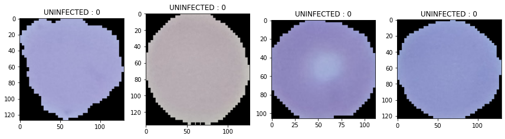

```python
plt.figure(figsize = (12,12))
for i in range(4):
    plt.subplot(1, 4, i+1)
    img = cv2.imread('/content/True_uninfected' + "/" + uninfected_data[i+1])
    plt.imshow(img)
    plt.title('UNINFECTED : 0')
    plt.tight_layout()
plt.show()
```

```python
data = []
labels = []
for img in parasitized_data:
    try:
        img_read = plt.imread('/content/True_parasitized' + "/" + img)
        img_resize = cv2.resize(img_read, (64, 64))
        img_array = img_to_array(img_resize)
        data.append(img_array)
        labels.append(1)
    except:
        None

for img in uninfected_data:
    try:
        img_read = plt.imread('/content/True_uninfected' + "/" + img)
        img_resize = cv2.resize(img_read, (64, 64))
        img_array = img_to_array(img_resize)
        data.append(img_array)
        labels.append(0)
    except:
        None
```

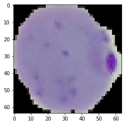

```python
plt.imshow(data[0])
plt.show()
```

```python
image_data = np.array(data)
labels = np.array(labels)
```

```python
idx = np.arange(image_data.shape[0])
np.random.shuffle(idx)
image_data = image_data[idx]
labels = labels[idx]
```

### Exploratory Data Analysis

Getting the counts for uninfected and parasatized RBC's in the Training data.

```python
df_train_labels=pd.DataFrame(data=y_train, index=None, columns=None)
print(df_train_labels)
```

```
         0    1
0      0.0  1.0
1      0.0  1.0
2      0.0  1.0
3      0.0  1.0
4      1.0  0.0
...    ...  ...
20923  0.0  1.0
20924  1.0  0.0
20925  1.0  0.0
20926  0.0  1.0
20927  0.0  1.0

[20928 rows x 2 columns]
```

```python
df_train_labels.value_counts()
```

```
0    1
1.0  0.0    10471
0.0  1.0    10457
dtype: int64
```

```python
df_test_labels=pd.DataFrame(data=y_test, index=None, columns=None)
print(df_test_labels)
```

```
        0    1
0     1.0  0.0
1     1.0  0.0
2     1.0  0.0
3     0.0  1.0
4     1.0  0.0
...   ...  ...
5228  0.0  1.0
5229  0.0  1.0
5230  1.0  0.0
5231  1.0  0.0
5232  0.0  1.0

[5233 rows x 2 columns]
```

```python
df_test_labels.value_counts()
```

```
0    1
0.0  1.0    2675
1.0  0.0    2558
dtype: int64
```

**Converting one hot encoded y_label data to single vectors**

```python
#creating new dataframes to convert one hot encoded data into a single vector for y_test and y_train labels
df_train_labels['New']=df_train_labels.values.argmax(1)+0
df_train_labels
```

[output not shown]

```python
single_y_train= df_train_labels['New']
single_y_train
```

```
0        1
1        1
2        1
3        1
4        0
        ..
20923    1
20924    0
20925    0
20926    1
20927    1
Name: New, Length: 20928, dtype: int64
```

```python
df_test_labels['New']=df_test_labels.values.argmax(1)+0
df_test_labels
```

|  | 0 | 1 | New |
| --- | --- | --- | --- |
| 0 | 1.0 | 0.0 | 0 |
| 1 | 1.0 | 0.0 | 0 |
| 2 | 1.0 | 0.0 | 0 |
| 3 | 0.0 | 1.0 | 1 |
| 4 | 1.0 | 0.0 | 0 |
| ... | ... | ... | ... |
| 5228 | 0.0 | 1.0 | 1 |
| 5229 | 0.0 | 1.0 | 1 |
| 5230 | 1.0 | 0.0 | 0 |
| 5231 | 1.0 | 0.0 | 0 |
| 5232 | 0.0 | 1.0 | 1 |

5233 rows × 3 columns

```python
single_y_test= df_test_labels['New']
single_y_test
```

```
0       0
1       0
2       0
3       1
4       0
       ..
5228    1
5229    1
5230    0
5231    0
5232    1
Name: New, Length: 5233, dtype: int64
```

Getting the counts for uninfected and parasaitized RBC's in the Test data.

**Visualizing the balance between uninfected and parasitized RBCs in the data sets.**

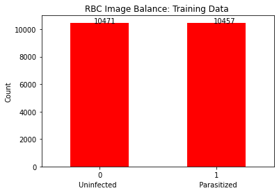

```python
# bar plot to get the count unifected and parasitized RBC images in Training data

single_y_train.value_counts().plot(kind='bar', rot = 0, color='red')
plt.text(x = -0.05, y = single_y_train.value_counts()[1]+1, s = single_y_train.value_counts()[0])
plt.text(x = 0.98, y = single_y_train.value_counts()[0]+2, s = single_y_train.value_counts()[1])
plt.title('RBC Image Balance: Training Data ')
plt.xlabel('Uninfected                                      Parasitized')
plt.ylabel('Count')
plt.show()
```

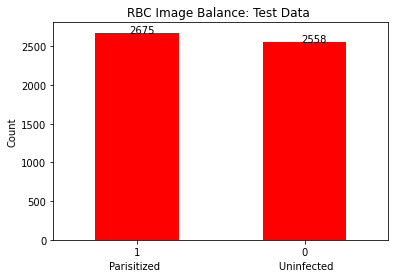

```python
# bar plot to get the count unifected and parasitized RBC images in Test data

single_y_test.value_counts().plot(kind='bar', rot = 0, color='red')
plt.text(x = -0.05, y = single_y_test.value_counts()[1]+0, s = single_y_test.value_counts()[1])
plt.text(x = 0.98, y = single_y_test.value_counts()[0]+1, s = single_y_test.value_counts()[0])
plt.title('RBC Image Balance: Test Data ')
plt.xlabel('Parisitized                                      Uninfected')
plt.ylabel('Count')
plt.show()
```

**Observations:**

- Although the data are not 100% perfectly balanced, the same train/test split as utilized in Fuhad et. al, 2020 was utilized.
- There were slightly more uninfected data in the training data from the corrected data.
- There are slightly more parasitized images than uninfected in the test set.

**Check the minimum and maximum range of pixel values for train and test images**

```python
# finding the maximum and minimum size of all images and pixel values for the training images

maxsize = []
minsize = []
maxpixel = []
minpixel = []
for image in x_train:
  maxsize.append(format(image.size))
  minsize.append(format(image.size))
  maxpixel.append(format(image.max()))
  minpixel.append(format(image.min()))
print ("Max image size of all images: ", max(maxsize))
print ("Min image size of all images: ", min(minsize))
print ("Max pixel size of all images: ", max(maxpixel))
print ("Min pixel size of all images: ", min(minpixel))
```

```
Max image size of all images:  12288
Min image size of all images:  12288
Max pixel size of all images:  1.0
Min pixel size of all images:  0.0
```

```python
# finding the maximum and minimum size of all images and pixel values for the test images

maxsize = []
minsize = []
maxpixel = []
minpixel = []
for image in x_test:
  maxsize.append(format(image.size))
  minsize.append(format(image.size))
  maxpixel.append(format(image.max()))
  minpixel.append(format(image.min()))
print ("Max image size of all images: ", max(maxsize))
print ("Min image size of all images: ", min(minsize))
print ("Max pixel size of all images: ", max(maxpixel))
print ("Min pixel size of all images: ", min(minpixel))
```

```
Max image size of all images:  12288
Min image size of all images:  12288
Max pixel size of all images:  0.9980935454368591
Min pixel size of all images:  0.0
```

**Observations and insights:**

- Using the above methods in the corrected malaria dataset, the pixel sizes have all been normalized.
- The image sizes are all standardized in both training and test data sets.

**Visualizing the normalized images from the training data**

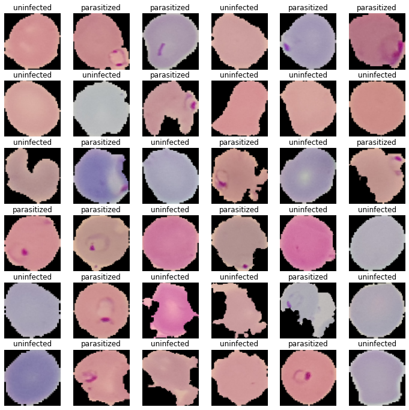

```python
#Visualization of unifected and parasitized RBC images
np.random.seed(10)
plt.figure(1 , figsize = (12 , 12))

for n in range(1, 37):
    plt.subplot(6, 6, n)
    index = int(np.random.randint(0, x_train.shape[0], 1))
    if single_y_train[index] == 1.0:
        plt.title('parasitized')
    else:
        plt.title('uninfected')
    plt.imshow(x_train[index])
    plt.axis('off')
```

All images appear to be clear and correctly labled with varrying staining, which may pose the greatest issue for automatic detection the neural network.

### **Plotting the mean images for Parasitized and Uninfected**

```python
# function to find the mean
def find_mean_img(full_mat, title):
    # calculate the average
    mean_img = np.mean(full_mat, axis = 0)[0]
    # reshape it back to a matrix
    plt.imshow(mean_img)
    plt.title(f'Average {title}')
    plt.axis('off')
    plt.show()
    return mean_img
```

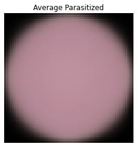

```python
# If the label=1 then the image is parasitised and if the label=0 then the image is uninfected
parasitized_data=[]                                # Create a list to store the parasitized data
for img, label in zip(x_train, single_y_train):
        if label==1:
              parasitized_data.append([img])

parasitized_mean = find_mean_img(np.array(parasitized_data), 'Parasitized')   # find the mean
```

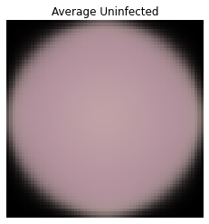

```python
# Similarly write the code to find the mean image of uninfected
# If the label=1 then the image is parasitised and if the label=0 then the image is uninfected
uninfected_data=[]                                # Create a list to store the uninfected data
for img, label in zip(x_train, single_y_train):
        if label==0:
             uninfected_data.append([img])

uninfected_mean = find_mean_img(np.array(uninfected_data), 'Uninfected')   # find the mean
```

**Observations:**

- The mean parasitized image looks much like the mean uninfected RBC.
- The only discernable difference is a sligtly darker cytosol, likely due to the presence of Plasmodium and varrying locations within the cytosol of the RBC. This likely then results in a mean image that is only a slight shade darker than the average uninfected.
- This may be of value in normalization.

# Creating Test and Train data splits

```python
from sklearn.model_selection import train_test_split
x_train, x_test, y_train, y_test = train_test_split(image_data, labels, test_size = 0.2, random_state = 101)
```

### **Normalize the images**

```python
# try to normalize the train and test images by dividing it by 255 and convert them to float32 using astype function
x_train = (x_train/255).astype('float32')
x_test = (x_test/255).astype('float32')
```

**Determine the shape of the data.**

```python
y_train = np_utils.to_categorical(y_train, num_classes = 2)
y_test = np_utils.to_categorical(y_test, num_classes = 2)
```

```python
print(f'SHAPE OF TRAINING IMAGE DATA : {x_train.shape}')
print(f'SHAPE OF TESTING IMAGE DATA : {x_test.shape}')
print(f'SHAPE OF TRAINING LABELS : {y_train.shape}')
print(f'SHAPE OF TESTING LABELS : {y_test.shape}')
```

```
SHAPE OF TRAINING IMAGE DATA : (20928, 64, 64, 3)
SHAPE OF TESTING IMAGE DATA : (5233, 64, 64, 3)
SHAPE OF TRAINING LABELS : (20928, 2)
SHAPE OF TESTING LABELS : (5233, 2)
```

The shape of the data is critical to forming the correct configuration of the input layer to the CNN. The shape shows the correct binary categorization (uninfected and parasitized). This will direct the use of:

- Binary crossentropy loss
- Softmax or sigmoid (will need to alter shape to 1) classification functions

#### **Importing the required libraries for model building**

```python
#Clearing backend
from tensorflow.keras import backend
from tensorflow.keras.utils import to_categorical
from tensorflow.keras.models import Sequential
from tensorflow.keras.layers import Conv2D,MaxPooling2D,Dense,Flatten,Dropout
from tensorflow.keras.callbacks import EarlyStopping, ModelCheckpoint
from random import shuffle

backend.clear_session()
#Fixing the seed for random number generators so that we can ensure we receive the same output everytime
np.random.seed(42)
import random
random.seed(42)
tf.random.set_seed(42)
```

```python
import keras
from keras.layers import Dense, Conv2D
from keras.layers import Flatten
from keras.layers import MaxPooling2D, GlobalAveragePooling2D
from keras.layers import Activation
from keras.layers import BatchNormalization
from keras.layers import Dropout
from keras.models import Sequential
from keras import backend as K

from keras import optimizers
```

# **Model 1: Base CNN Model.**

- Starting with a simple initial CNN model and some popular configurations including ReLU activation function in hidden layers, binary cross entropy loss function and softmax activation function on the final output layer.

#### **Building the Model**

```python
#Clearing backend
from tensorflow.keras import backend
backend.clear_session()

#Fixing the seed for random number generators
np.random.seed(42)
import random
random.seed(42)
tf.random.set_seed(42)
```

```python
def CNNbuild1(height, width, classes, channels):
    model = Sequential()

    inputShape = (height, width, channels)
    chanDim = -1

    if K.image_data_format() == 'channels_first':
        inputShape = (channels, height, width)
    model.add(Conv2D(32, (3,3), activation = 'relu', input_shape = inputShape))
    model.add(MaxPooling2D(2,2))

    model.add(Conv2D(64, (3,3), activation = 'relu'))
    model.add(MaxPooling2D(2,2))

    model.add(Flatten())

    model.add(Dense(256, activation = 'relu'))
    model.add(Dropout(0.2))
    model.add(Dense(classes, activation = 'softmax'))

    return model
```

```python
#instantiate model
height = 64
width = 64
classes = 2
channels = 3
model = CNNbuild1(height = height, width = width, classes = classes, channels = channels)
model.summary()
```

```
Model: "sequential"
_________________________________________________________________
 Layer (type)                Output Shape              Param #
=================================================================
 conv2d (Conv2D)             (None, 62, 62, 32)        896

 max_pooling2d (MaxPooling2D  (None, 31, 31, 32)       0
 )

 conv2d_1 (Conv2D)           (None, 29, 29, 64)        18496

 max_pooling2d_1 (MaxPooling  (None, 14, 14, 64)       0
 2D)

 flatten (Flatten)           (None, 12544)             0

 dense (Dense)               (None, 256)               3211520

 dropout (Dropout)           (None, 256)               0

 dense_1 (Dense)             (None, 2)                 514

=================================================================
Total params: 3,231,426
Trainable params: 3,231,426
Non-trainable params: 0
_________________________________________________________________
```

```python
!ls
```

```
drive  sample_data  tf_logs  True_parasitized  True_uninfected
```

```python
base_logdir = "./tf_logs"
if os.path.isdir(base_logdir):
  !rm -r tf_logs/

experiment_name = "base_CNN"
logdir = os.path.join(base_logdir, experiment_name)
tensorboard_callback = tf.keras.callbacks.TensorBoard(logdir, histogram_freq=1)
```

#### **Compiling the model**

```python
from tensorflow.keras import optimizers
model.compile(loss="binary_crossentropy", optimizer='Adam', metrics = ['accuracy', tf.keras.metrics.RecallAtPrecision(precision=0.8)])
```

**Using callbacks**

```python
callbacks = [EarlyStopping(monitor='val_loss', patience=5),
             ModelCheckpoint('.mdl_wts.hdf5', monitor='val_loss', save_best_only=True), tensorboard_callback]
```

**Fit and train the model**

```python
history = model.fit(x_train,y_train,batch_size=16,callbacks=callbacks,validation_split=0.2,epochs=20,verbose=1)
```

#### **Evaluating the model**

**Plotting the train and validation accuracy**

```python
# function to plot train and validation accuracy
def plot_accuracy(history):
    N = len(history.history["accuracy"])
    plt.figure(figsize=(7,7))
    plt.plot(np.arange(0, N), history.history["accuracy"], label="train_accuracy", ls='--')
    plt.plot(np.arange(0, N), history.history["val_accuracy"], label="val_accuracy", ls='--')
    plt.title("Accuracy vs Epoch")
    plt.xlabel("Epochs")
    plt.ylabel("Accuracy")
    plt.legend(loc="upper left")
```

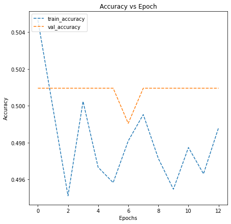

```python
plot_accuracy(history)
```

```python
# Evaluate the model against test data to calculate the accuracy
accuracy = model.evaluate(x_test, y_test, verbose=1)
print('\n', 'Test_Accuracy:-', accuracy[1])
```

```
 Test_Accuracy:- 0.48442575335502625
```

**Generate the classification report and confusion matrix**

```
              precision    recall  f1-score   support

           0       0.48      1.00      0.65      2535
           1       0.00      0.00      0.00      2698

    accuracy                           0.48      5233
   macro avg       0.24      0.50      0.33      5233
weighted avg       0.23      0.48      0.32      5233
```

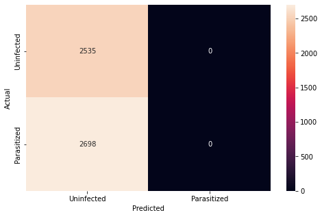

```python
from sklearn.metrics import classification_report
from sklearn.metrics import confusion_matrix

pred = model.predict(x_test)
pred = np.argmax(pred,axis = 1)
y_true = np.argmax(y_test,axis = 1)

#Printing the classification report
print(classification_report(y_true,pred))

#Plotting the heatmap using confusion matrix
cm = confusion_matrix(y_true,pred)
plt.figure(figsize=(8,5))
sns.heatmap(cm, annot=True,  fmt='.0f', xticklabels=['Uninfected', 'Parasitized'], yticklabels=['Uninfected', 'Parasitized'])
plt.ylabel('Actual')
plt.xlabel('Predicted')
plt.show()
```

##### **Model 1 Observations and insights:**